# Civilian Killings in Darfur over Time - Visual 2

Rob Boswell

7-27-2023

```r
library(stringr)

# Get the current page number from the file name
current_page <- as.numeric(str_extract(knitr::current_input(), "\\d+"))

# Set the total number of pages
total_pages <- 9

# Generate the URLs for the previous and next pages
previous_page <- ifelse(current_page > 1, paste0("visual_", current_page - 1, "-darfur_violence-code_included.html"), NA)
next_page <- ifelse(current_page < total_pages, paste0("visual_", current_page + 1, "-darfur_violence-code_included.html"), NA)
```

- Previous Page
- Next Page

#### In June 2017, the UN Security Council adopted [Resolution 2363 (2017)](https://documents-dds-ny.un.org/doc/UNDOC/GEN/N17/191/58/PDF/N1719158.pdf) in which it decided to close down bases starting that same year, in multiple phases. [The goal was set to end the mission within 2 years](https://reliefweb.int/report/sudan/unamid-full-exit-darfur-be-completed-within-two-years-fm).

```r
# Note: All code, insights shared, and methodological notes in this document and other documents in this portfolio ARE NOT open source and MUST be cited.

library(tidyverse)
library(ggplot2)
library(ggthemes)
library(ggimage)


setwd("C:/Users/rsb84/Desktop/RB/COLUMBIA/QMSS/COURSES/Spring_2021/Data Visualization/End_project/")

ACLED_data <- readxl::read_excel("ACLED-DARFUR-VAC-2008-2021 (After Course Ended-for 2023 Portfolio).xlsx", col_types = c("date", "numeric", "text",
         "text", "text", "text", "text", "text",
         "text", "text", "text", "text", "text",
         "numeric", "numeric", "text", "text",
         "numeric", "numeric"))

fatalities_by_year=ACLED_data %>% group_by(year) %>% tally(fatalities)

ak47_icon = "C:/Users/rsb84/Desktop/RB/COLUMBIA/QMSS/COURSES/Spring_2021/Data Visualization/End_project/ak-47_5_thumbnail.png"

fatalities_by_year$image = c(ak47_icon, ak47_icon, ak47_icon, ak47_icon, ak47_icon, ak47_icon, ak47_icon, ak47_icon, ak47_icon, ak47_icon, ak47_icon, ak47_icon, ak47_icon, ak47_icon)


visual_2 <- ggplot(fatalities_by_year, aes(x=fatalities_by_year$year, y=fatalities_by_year$n, fill=as.character(year))) + geom_vline(xintercept=as.integer(2017), color = "green4", linetype="dashed", size = 1) + geom_vline(xintercept=as.integer(2019), color = "purple",linetype="dashed", size = 1) + geom_bar(stat="identity", width=0.45) + scale_fill_manual("legend", values = c("2008" = "gray75", "2009" = "gray75", "2010" = "gray75", "2011" = "gray75", "2012" = "gray75", "2013" = "gray75", "2014" = "gray75", "2015" = "gray75", "2016" = "gray75", "2017" = "deepskyblue1", "2018" = "deepskyblue1", "2019" = "deepskyblue1", "2020" = "deepskyblue1", "2021" = "deepskyblue1")) + geom_text(aes(label=n), vjust=1.5, color="red", size=3.2) + geom_image(image=fatalities_by_year$image, size=0.09, nudge_x=-.05, nudge_y=15) +  scale_x_continuous("Year of Mission") + scale_y_continuous("Civilian Killings") + theme_wsj() + theme(title =element_text(size=13, color= "steelblue", face='bold'), axis.title.x=element_blank(), axis.title.y=element_blank(), axis.text.x = element_text(size = 9.7), axis.text.y = element_text(size = 12), legend.position="none") + labs(title="Civilian Killings During Years UNAMID Troops Were Present", subtitle="", caption = "Source: The Armed Conflict Location & Event Data Project dataset, dates: Jan. 2008-Dec. 2021") + annotate("text", x= as.numeric(2015.8), y= as.numeric(700), label="The First Year\n UN Bases Began\nClosing", fontface=2, size=3, color="green4") + annotate("text", x= as.numeric(2020.5), y= as.numeric(685), label="The Year the Security\n Council Decided to\n Completely Withdraw\nUNAMID", fontface=2, size=3, color="purple")
```

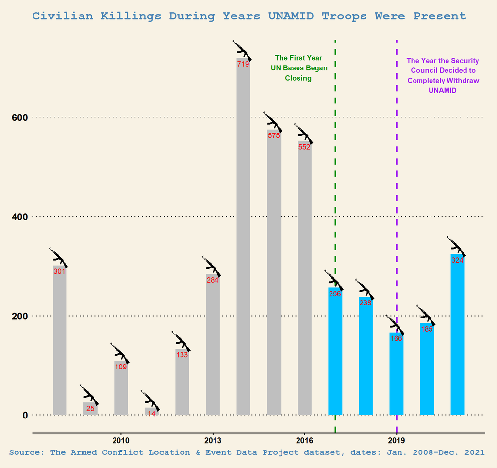

```r
visual_2
```

#### Yet, due to trends in violence at the time this resolution was adopted, the question remains: was it premature for the UN to begin withdrawing from Darfur? 552 civilians were killed by state and non-state armed groups in the year prior to the UN adopting Resolution 2363. And even though civilian fatalities dropped in 2017, they were still almost as high as when the mission began in 2008. In fact, at no point before 2017 did civilian fatality trends stabilized at low levels.

#### Retrospectively, we also see that between the end of 2020 and the end of 2021 there was a 75% increase in civilian killings.

```r
# Get the current page number from the file name
current_page <- as.numeric(str_extract(knitr::current_input(), "\\d+"))

# Set the total number of pages
total_pages <- 9

# Generate the URLs for the previous and next pages
previous_page <- ifelse(current_page > 1, paste0("visual_", current_page - 1, "-darfur_violence-code_included.html"), NA)
next_page <- ifelse(current_page < total_pages, paste0("visual_", current_page + 1, "-darfur_violence-code_included.html"), NA)
```

- Previous Page
- Next Page